# Analyse des avis et alertes ANSSI — Visualisation & Machine Learning

### Régression — prédiction du score EPSS

```
Données régression : 125,755 lignes
Train : 100,604 | Test : 25,151

[+] Random Forest Régression entraîné.

=== Métriques de régression ===
  MAE  : 0.0194  (erreur moyenne sur un score entre 0 et 1)
  RMSE : 0.0798
  R²   : 0.1664  → le modèle explique 16.6% de la variance EPSS
```

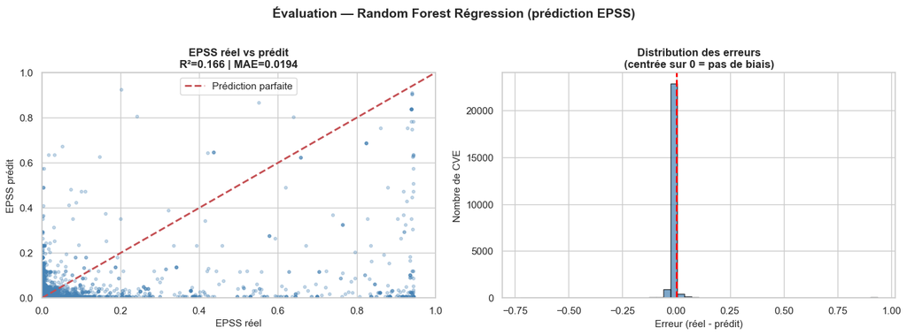

```python
# --- Préparation ---
df_epss     = df[df['epss_score'].notna()].copy()
imputer_reg = SimpleImputer(strategy='median')
X_reg       = imputer_reg.fit_transform(df_epss[FEATURES_REG])
y_reg       = df_epss['epss_score'].values

X_train_r, X_test_r, y_train_r, y_test_r = train_test_split(
    X_reg, y_reg, test_size=0.2, random_state=42
)
print(f"Données régression : {len(df_epss):,} lignes")
print(f"Train : {X_train_r.shape[0]:,} | Test : {X_test_r.shape[0]:,}")

# --- Entraînement ---
rf_reg = RandomForestRegressor(n_estimators=100, max_depth=10, random_state=42)
rf_reg.fit(X_train_r, y_train_r)
print("\n[+] Random Forest Régression entraîné.")

# --- Évaluation ---
y_pred_r = rf_reg.predict(X_test_r)
mae  = mean_absolute_error(y_test_r, y_pred_r)
rmse = mean_squared_error(y_test_r, y_pred_r) ** 0.5
r2   = r2_score(y_test_r, y_pred_r)

print(f"\n=== Métriques de régression ===")
print(f"  MAE  : {mae:.4f}  (erreur moyenne sur un score entre 0 et 1)")
print(f"  RMSE : {rmse:.4f}")
print(f"  R²   : {r2:.4f}  → le modèle explique {r2*100:.1f}% de la variance EPSS")

# --- Visualisation ---
fig, axes = plt.subplots(1, 2, figsize=(14, 5))

axes[0].scatter(y_test_r, y_pred_r, alpha=0.3, s=10, color='steelblue')
axes[0].plot([0, 1], [0, 1], 'r--', linewidth=2, label='Prédiction parfaite')
axes[0].set_xlabel("EPSS réel", fontsize=11)
axes[0].set_ylabel("EPSS prédit", fontsize=11)
axes[0].set_title(f"EPSS réel vs prédit\nR²={r2:.3f} | MAE={mae:.4f}",
                  fontsize=12, fontweight='bold')
axes[0].set_xlim(0, 1)
axes[0].set_ylim(0, 1)
axes[0].legend()

erreurs = y_test_r - y_pred_r
axes[1].hist(erreurs, bins=50, color='steelblue', edgecolor='black', alpha=0.7)
axes[1].axvline(0, color='red', linestyle='--', linewidth=2)
axes[1].set_xlabel("Erreur (réel - prédit)", fontsize=11)
axes[1].set_ylabel("Nombre de CVE", fontsize=11)
axes[1].set_title("Distribution des erreurs\n(centrée sur 0 = pas de biais)",
                  fontsize=12, fontweight='bold')

plt.suptitle("Évaluation — Random Forest Régression (prédiction EPSS)",
             fontsize=14, fontweight='bold', y=1.02)
plt.tight_layout()
plt.show()
```

*Le scatter plot révèle deux comportements distincts : le modèle prédit correctement les EPSS faibles (masse de points concentrée près de zéro), mais sous-estime systématiquement les scores élevés — les points s'écartent nettement de la diagonale rouge au-delà de 0.2. Ce phénomène est caractéristique des distributions fortement asymétriques où les valeurs extrêmes sont sous-représentées dans les données d'entraînement (125 755 lignes, dont 75% ont un EPSS < 0.001). La distribution des erreurs (droite) est centrée sur zéro, attestant de l'absence de biais systématique. Le R² de 16.6% et le MAE de 0.0194 confirment des prédictions précises en valeur absolue, mais une capacité limitée à expliquer la variance — conséquence directe des facteurs externes non capturés (activité des hackers, publication d'exploits publics).*

```python
# ==============================================================================
# SYNTHÈSE FINALE — MODÈLES RETENUS
# ==============================================================================

print("=" * 65)
print("  BILAN ML — MODÈLES RETENUS ET JUSTIFICATIONS")
print("=" * 65)

synthese = pd.DataFrame({
    "Modèle": [
        "K-Means (k=4)",
        "DBSCAN (eps=1.0)",
        "XGBoost Classification",
        "Random Forest Régression"
    ],
    "Type": [
        "Non supervisé",
        "Non supervisé",
        "Supervisé",
        "Régression"
    ],
    "Performance": [
        "4 clusters métier cohérents",
        "79 CVE ultra-dangereux isolés (EPSS > 0.47)",
        f"CV 5-fold : {cv_scores.mean():.1%} ± {cv_scores.std():.1%}",
        f"R²={r2:.3f} | MAE={mae:.4f}"
    ],
    "Valeur ajoutée": [
        "Segmentation macro des risques",
        "Détection ProxyLogon, CitrixBleed...",
        f"Classification de {len(df_inconnus):,} CVE sans CVSS",
        "Prédiction probabilité d'exploitation"
    ]
})

print(synthese.to_string(index=False))

print(f"""
CONCLUSIONS :

► K-Means et DBSCAN sont complémentaires :
  K-Means donne une vue macro (4 segments de risque).
  DBSCAN identifie précisément les menaces actives sans règle manuelle.

► XGBoost ({cv_scores.mean():.1%}) nettement supérieur à Random Forest (45.1%) :
  Le boosting séquentiel gère mieux les classes déséquilibrées.
  {cv_scores.mean():.1%} reste modeste — sans cvss_score, la prédiction est difficile
  mais utile pour pré-classer les CVE en attente de notation MITRE.

► Régression EPSS : R²={r2*100:.1f}% reflète une limite des données.
  L'EPSS dépend de facteurs comportementaux externes (activité des
  hackers, exploits publics) non capturés dans nos features.
  Les erreurs sont centrées sur 0 — pas de biais systématique.
""")
```

[output not shown]

[output not shown]